# 基礎 R 語法寫作示範

### 因子

定義: 索引資料框架的欄位，統計函式必須使用因子分組資料。

```r
x<-rep(1:4,each=25)
factor(x)  ## 將向量轉換成因子，設定層次(levels)及層次順序
```

```
##   [1] 1 1 1 1 1 1 1 1 1 1 1 1 1 1 1 1 1 1 1 1 1 1 1 1 1 2 2 2 2 2 2 2 2 2 2 2 2
##  [38] 2 2 2 2 2 2 2 2 2 2 2 2 2 3 3 3 3 3 3 3 3 3 3 3 3 3 3 3 3 3 3 3 3 3 3 3 3
##  [75] 3 4 4 4 4 4 4 4 4 4 4 4 4 4 4 4 4 4 4 4 4 4 4 4 4 4
## Levels: 1 2 3 4
```

```r
x<-1:100
cut(x,4)   ## 指定切割區間數，將向量轉換成因子
```

```
##   [1] (0.901,25.8] (0.901,25.8] (0.901,25.8] (0.901,25.8] (0.901,25.8]
##   [6] (0.901,25.8] (0.901,25.8] (0.901,25.8] (0.901,25.8] (0.901,25.8]
##  [11] (0.901,25.8] (0.901,25.8] (0.901,25.8] (0.901,25.8] (0.901,25.8]
##  [16] (0.901,25.8] (0.901,25.8] (0.901,25.8] (0.901,25.8] (0.901,25.8]
##  [21] (0.901,25.8] (0.901,25.8] (0.901,25.8] (0.901,25.8] (0.901,25.8]
##  [26] (25.8,50.5]  (25.8,50.5]  (25.8,50.5]  (25.8,50.5]  (25.8,50.5]
##  [31] (25.8,50.5]  (25.8,50.5]  (25.8,50.5]  (25.8,50.5]  (25.8,50.5]
##  [36] (25.8,50.5]  (25.8,50.5]  (25.8,50.5]  (25.8,50.5]  (25.8,50.5]
##  [41] (25.8,50.5]  (25.8,50.5]  (25.8,50.5]  (25.8,50.5]  (25.8,50.5]
##  [46] (25.8,50.5]  (25.8,50.5]  (25.8,50.5]  (25.8,50.5]  (25.8,50.5]
##  [51] (50.5,75.2]  (50.5,75.2]  (50.5,75.2]  (50.5,75.2]  (50.5,75.2]
##  [56] (50.5,75.2]  (50.5,75.2]  (50.5,75.2]  (50.5,75.2]  (50.5,75.2]
##  [61] (50.5,75.2]  (50.5,75.2]  (50.5,75.2]  (50.5,75.2]  (50.5,75.2]
##  [66] (50.5,75.2]  (50.5,75.2]  (50.5,75.2]  (50.5,75.2]  (50.5,75.2]
##  [71] (50.5,75.2]  (50.5,75.2]  (50.5,75.2]  (50.5,75.2]  (50.5,75.2]
##  [76] (75.2,100]   (75.2,100]   (75.2,100]   (75.2,100]   (75.2,100]
##  [81] (75.2,100]   (75.2,100]   (75.2,100]   (75.2,100]   (75.2,100]
##  [86] (75.2,100]   (75.2,100]   (75.2,100]   (75.2,100]   (75.2,100]
##  [91] (75.2,100]   (75.2,100]   (75.2,100]   (75.2,100]   (75.2,100]
##  [96] (75.2,100]   (75.2,100]   (75.2,100]   (75.2,100]   (75.2,100]
## Levels: (0.901,25.8] (25.8,50.5] (50.5,75.2] (75.2,100]
```

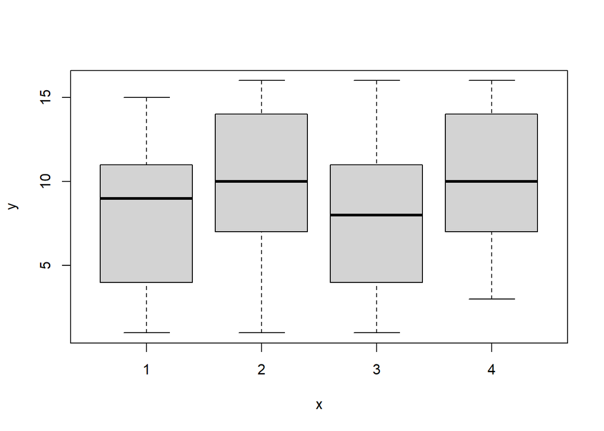

```r
df <- data.frame(y = sample(1:16,size = 100,replace = TRUE), x = as.factor(rep(1:4,each=25)) )
plot(y ~ x,data=df)
```

### 列表

定義: 集合型態及數量不一致的資料

```r
l<-list(x= 1:5,
        y= c('a','b'),
        z= df)

l[[2]]      ## 取得第二個物件數值
```

```
## [1] "a" "b"
```

```r
l[3]        ## 取得列表第三個物件名稱與數值
```

```
## $z
##      y x
## 1    7 1
## 2    9 1
## 3    9 1
## 4    3 1
## 5    3 1
## 6    6 1
## 7    4 1
## 8   13 1
## 9   14 1
## 10   4 1
## 11   9 1
## 12   9 1
## 13  12 1
```

[output cut: 87 more lines]

```r
l$x         ## 取得列表x物件數值
```

```
## [1] 1 2 3 4 5
```

```r
l['z']      ## 取得列表z物件名稱與數值
```

```
## $z
##      y x
## 1    7 1
## 2    9 1
## 3    9 1
## 4    3 1
## 5    3 1
## 6    6 1
## 7    4 1
## 8   13 1
## 9   14 1
## 10   4 1
## 11   9 1
## 12   9 1
## 13  12 1
```

[output cut: 87 more lines]

## 常用內建函式

### 數學運算函式

有至少一個欄位的資料，使用數學運算函式能做簡單統計。

```r
x <- runif(10)
y <- rnorm(10)

log(x)            ##自然對數
```

```
##  [1] -2.2098940 -1.4485347 -1.2754271 -0.3863455 -0.9332931 -0.3900075
##  [7] -0.9000852 -0.8343352 -0.2740980 -0.1494294
```

```r
exp(x)            ##自然指數
```

```
##  [1] 1.115957 1.264800 1.322219 1.972961 1.481798 1.968067 1.501606 1.543670
##  [9] 2.138827 2.365996
```

```r
max(x)            ##最大值
```

```
## [1] 0.8611993
```

```r
min(x)            ##最小值
```

```
## [1] 0.1097123
```

```r
round(exp(x), 2)  ##顯示數值到小數點第2位
```

```
##  [1] 1.12 1.26 1.32 1.97 1.48 1.97 1.50 1.54 2.14 2.37
```

```r
signif(log(x), 3) ##小數點第3位起簡寫數值
```

```
##  [1] -2.210 -1.450 -1.280 -0.386 -0.933 -0.390 -0.900 -0.834 -0.274 -0.149
```

```r
quantile(x)       ##百分位數
```

```
##        0%       25%       50%       75%      100%
## 0.1097123 0.3077979 0.4203490 0.6789147 0.8611993
```

```r
rank(x)           ##次序位數
```

```
##  [1]  1  2  3  8  4  7  5  6  9 10
```

```r
sum(x)            ##總和
```

```
## [1] 4.835937
```

```r
mean(x)           ##平均
```

```
## [1] 0.4835937
```

```r
median(x)         ##中位數
```

```
## [1] 0.420349
```

```r
var(x)            ##樣本變異數
```

```
## [1] 0.06165004
```

```r
sd(x)             ##樣本標準差
```

```
## [1] 0.2482943
```

```r
cor(x,y)          ##相關
```

```
## [1] 0.01682948
```

### 統計函式

預設內建統計函式已經涵蓋基礎統計方法

```r
prop.test(x,seq(10,100,by=10))   ## 分組平均比例顯著性考驗
```

```
##
##  10-sample test for equality of proportions without continuity
##  correction
##
## data:  x out of seq(10, 100, by = 10)
## X-squared = 0.55949, df = 9, p-value = 1
## alternative hypothesis: two.sided
## sample estimates:
##      prop 1      prop 2      prop 3      prop 4      prop 5      prop 6
## 0.010971227 0.011745712 0.009310388 0.016988392 0.007865131 0.011284197
##      prop 7      prop 8      prop 9     prop 10
## 0.005807643 0.005427038 0.008447306 0.008611993
```

```r
t.test(x,y)                      ## 獨立分組平均數 t檢定
```

```
##
##  Welch Two Sample t-test
##
## data:  x and y
## t = 1.5587, df = 9.9596, p-value = 0.1503
## alternative hypothesis: true difference in means is not equal to 0
## 95 percent confidence interval:
##  -0.2337581  1.3202625
## sample estimates:
##  mean of x  mean of y
##  0.4835937 -0.0596585
```

```r
group <- factor(rep(c("a","b","c"),c(3,3,4) ))
pairwise.t.test(x,group)    ## 計算t檢定的相依樣本變數相關性
```

```
##
##  Pairwise comparisons using t tests with pooled SD
##
## data:  x and group
##
##   a     b
## b 0.076 -
## c 0.063 0.821
##
## P value adjustment method: holm
```

```r
aov.1 <- aov(x~group)                ## 變異數分析
lm.1 <- lm(x~group)                 ## 線性模型
glm.1 <- glm(x~group)                ## 通用線性模型

summary(glm.1)                   ## 簡報變異數分析, 線性模型, 通用線性模型
```

```
##
## Call:
## glm(formula = x ~ group)
##
## Deviance Residuals:
##      Min        1Q    Median        3Q       Max
## -0.20900  -0.16060   0.04913   0.09563   0.24566
##
## Coefficients:
##             Estimate Std. Error t value Pr(>|t|)
## (Intercept)   0.2080     0.1041   1.998   0.0859 .
## groupb        0.3753     0.1472   2.550   0.0381 *
## groupc        0.4076     0.1377   2.960   0.0211 *
## ---
## Signif. codes:  0 '***' 0.001 '**' 0.01 '*' 0.05 '.' 0.1 ' ' 1
##
## (Dispersion parameter for gaussian family taken to be 0.03250139)
##
##     Null deviance: 0.55485  on 9  degrees of freedom
## Residual deviance: 0.22751  on 7  degrees of freedom
## AIC: -1.4527
##
## Number of Fisher Scoring iterations: 2
```

### 機率分佈函式

使用機率分佈函式製造符合假設的模擬資料，預覽研究設計的合理性與可執行程度。

```r
##常態分佈
norm_data <- rnorm(100)   ## 製造隨機變數
pnorm(norm_data)          ## 累積機率函數
```

```
##   [1] 0.511818722 0.528197230 0.806257959 0.663110218 0.577459701 0.163710770
##   [7] 0.243985175 0.983917183 0.058142202 0.004315057 0.385448269 0.228004765
##  [13] 0.804911385 0.302604457 0.151559213 0.544692017 0.542362573 0.007197635
##  [19] 0.037259712 0.724940836 0.488882865 0.531323755 0.992170175 0.069239582
##  [25] 0.978199043 0.073253398 0.001973101 0.553173747 0.210628005 0.188412162
##  [31] 0.761909583 0.131724295 0.589672377 0.454968829 0.094633519 0.468221689
##  [37] 0.970285643 0.327576360 0.888312975 0.798949402 0.218118679 0.558900375
##  [43] 0.380713982 0.779811579 0.141196367 0.858054495 0.920942277 0.781069739
##  [49] 0.213405383 0.905578633 0.260644816 0.875675009 0.450664927 0.483139225
##  [55] 0.382430326 0.770389849 0.695413620 0.352796222 0.945055188 0.526267843
##  [61] 0.699129007 0.555892288 0.688561775 0.777178405 0.750814844 0.119140784
##  [67] 0.395385369 0.826755357 0.491371131 0.084368741 0.955318635 0.107745785
##  [73] 0.396795975 0.898234457 0.413503511 0.443954135 0.054459252 0.855430105
##  [79] 0.467491176 0.976216715 0.245624424 0.720841465 0.962893935 0.940897389
##  [85] 0.452361287 0.322529190 0.893556401 0.659931221 0.355857729 0.686593700
##  [91] 0.432687381 0.647718070 0.150522968 0.160366066 0.600580484 0.400344119
##  [97] 0.497175911 0.644863691 0.397514132 0.861568013
```

```r
dnorm(norm_data)          ## 機率密度函數
```

```
##   [1] 0.398767202 0.397945375 0.274624702 0.365114265 0.391398554 0.246973790
##   [7] 0.313662466 0.040205072 0.116219905 0.012678518 0.382380938 0.302167345
##  [13] 0.275785100 0.349048651 0.234769594 0.396436315 0.396690979 0.019971598
##  [19] 0.081331984 0.333707256 0.398787372 0.397711924 0.021508965 0.133143537
##  [25] 0.052084173 0.139030294 0.006262715 0.395393332 0.288707035 0.269966665
##  [31] 0.309518577 0.213480334 0.388821271 0.396398095 0.168537761 0.397675937
##  [37] 0.067504114 0.361074408 0.190097210 0.280844157 0.294634854 0.394586276
##  [43] 0.380972959 0.296239021 0.223865960 0.224670000 0.147339264 0.295265605
##  [49] 0.290927399 0.168259124 0.324779415 0.205075926 0.395887876 0.398585928
##  [55] 0.381490187 0.303359795 0.350067534 0.371465901 0.111153572 0.398077181
##  [61] 0.348148273 0.395020559 0.353503737 0.298258989 0.317225924 0.199029068
##  [67] 0.385145842 0.256128747 0.398848958 0.154741291 0.094246039 0.185257130
##  [73] 0.385517508 0.177752123 0.389528290 0.394998942 0.110376249 0.227467083
##  [79] 0.397617014 0.056047512 0.314795073 0.336131852 0.081057824 0.117724335
##  [85] 0.396094559 0.358784915 0.183639645 0.366438694 0.372609881 0.354466119
##  [91] 0.393249965 0.371271255 0.233700210 0.243675503 0.386195033 0.386429562
##  [97] 0.398932285 0.372342580 0.385704744 0.220877218
```

```r
qnorm(pnorm(norm_data))   ## 量數 = 隨機變數
```

```
##   [1]  0.02962948  0.07073893  0.86418898  0.42096647  0.19539900 -0.97932071
##   [7] -0.69354061  2.14234619 -1.57056208 -2.62636923 -0.29120239 -0.74543378
##  [13]  0.85929600 -0.51692443 -1.02976907  0.11226163  0.10638757 -2.44724563
##  [19] -1.78341100  0.59758282 -0.02787013  0.07859786  2.41675275 -1.48147830
##  [25]  2.01789773 -1.45198133 -2.88243056  0.13368394 -0.80424411 -0.88376270
##  [31]  0.71245861 -1.11827727  0.22670229 -0.11311718 -1.31275049 -0.07974084
##  [37]  1.88500833 -0.44661547  1.21760517  0.83787449 -0.77856270  0.14818186
##  [43] -0.30360615  0.77155701 -1.07495978  1.07161942  1.41143820  0.77581111
##  [49] -0.79466093  1.31401031 -0.64135874  1.15363466 -0.12398159 -0.04227629
##  [55] -0.29910406  0.74013134  0.51125464 -0.37778214  1.59868945  0.06589137
##  [61]  0.52189709  0.14056269  0.49177777  0.76269856  0.67705618 -1.17929289
##  [67] -0.26530990  0.94142075 -0.02163105 -1.37627186  1.69876893 -1.23860566
##  [73] -0.26164915  1.27155553 -0.21854176 -0.14095148 -1.60307315  1.06001057
##  [79] -0.08157793  1.98122032 -0.68832388  0.58534306  1.78530332  1.56235143
##  [85] -0.11969776 -0.46063795  1.24566557  0.41227543 -0.36955316  0.48621802
##  [91] -0.16953638  0.37916699 -1.03419302 -0.99295449  0.25484990 -0.25245650
##  [97] -0.00707900  0.37148998 -0.25978676  1.08739116
```

比照以上的示範，自由測試秘訣速查表列出的其他機率函式：卜瓦松分佈,二項分佈,均勻分佈。

### 繪圖函式

有上百筆資料時，視覺化是理解資料的最佳方式

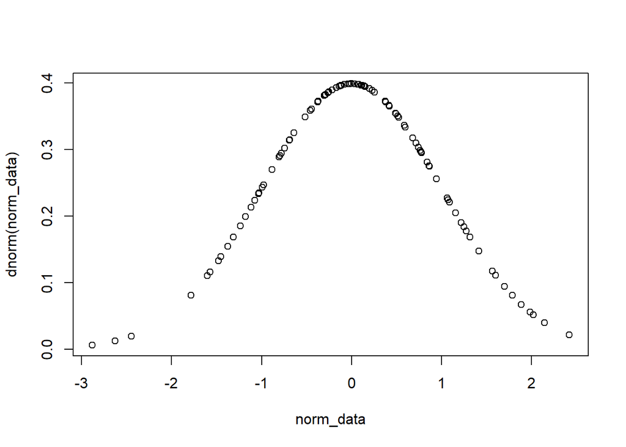

```r
plot(dnorm(norm_data)~norm_data)  ## 視覺化機率密度函數
```

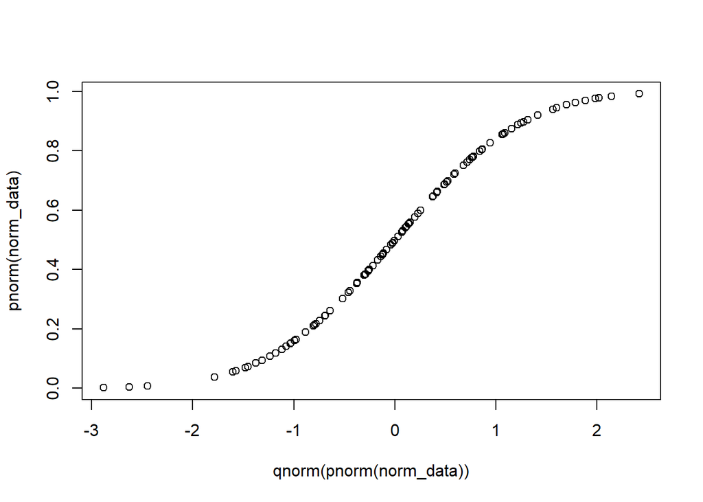

```r
plot(pnorm(norm_data)~qnorm(pnorm(norm_data)))  ## 視覺化累積機率函數
```

比照以上的示範，嘗試視覺化秘訣速查表列出的其他機率函式：卜瓦松分佈,二項分佈,均勻分佈。